# Food Accessibility and COVID-19 Cases in Washington

Bruce Chen, Christine Nguyen, Abbie Sawyer, Annie Tu

2/19/2021

### Introduction:

Food accessibility has become a major concern for people during the pandemic, even more so than ever before. Due to rising unemployment and public regulation policies, the stability people may have experienced previously with food has undoubtedly changed. We wanted to investigate the relationship between COVID-19, the number of operating restaurants, and emergency food resources, to discover how much of an effect the pandemic has had on people’s ability to access food, specifically in King County. This will give us a better understanding of the situation, which can help both our own communities as well as others moving forward.  
Our datasets come from data.gov, data.seattle.gov, and kingcounty.gov. They contain data on Emergency Food & Meals locations in Seattle and King County, restaurants still open during COVID-19, and COVID-19 data in King County.

### Summary Information:

**King County Municipalities Emergency Food Sources & Covid Data**

| City | Number of Food Sources | Positive Tests | Deaths | Deaths per Food Source | Positive Tests per Food Source |
| --- | --- | --- | --- | --- | --- |
| Auburn | 26 | 5176 | 83 | 3 | 199 |
| Bellevue | 19 | 3364 | 56 | 3 | 177 |
| Black Diamond | 3 | 113 | 1 | 0 | 38 |
| Bothell | 14 | 728 | 14 | 1 | 52 |
| Bryn Mawr-Skyway | 13 | 807 | 10 | 1 | 62 |
| Burien | 8 | 2684 | 38 | 5 | 336 |
| Carnation | 5 | 63 | 0 | 0 | 13 |
| Cottage Lake | 1 | 375 | 6 | 6 | 375 |
| Covington | 7 | 870 | 9 | 1 | 124 |
| Des Moines | 18 | 1807 | 20 | 1 | 100 |
| Duvall | 5 | 179 | 1 | 0 | 36 |
| Enumclaw | 11 | 583 | 29 | 3 | 53 |
| Fairwood | 9 | 663 | 10 | 1 | 74 |
| Fall City | 3 | 54 | 0 | 0 | 18 |
| Federal Way | 54 | 6217 | 90 | 2 | 115 |
| Issaquah | 9 | 922 | 52 | 6 | 102 |
| Kenmore | 12 | 534 | 11 | 1 | 44 |
| Kent | 40 | 7560 | 90 | 2 | 189 |
| Kirkland | 17 | 2096 | 64 | 4 | 123 |
| Lakeland North | 13 | 811 | 8 | 1 | 62 |
| Maple Valley | 4 | 783 | 3 | 1 | 196 |
| Mercer Island | 3 | 458 | 6 | 2 | 153 |
| North Bend | 4 | 310 | 12 | 3 | 78 |
| Pacific | 5 | 368 | 4 | 1 | 74 |
| Ravensdale | 1 | 54 | 0 | 0 | 54 |
| Redmond | 12 | 1209 | 59 | 5 | 101 |
| Renton | 25 | 4818 | 57 | 2 | 193 |
| Sammamish | 4 | 1005 | 9 | 2 | 251 |
| SeaTac | 12 | 2163 | 22 | 2 | 180 |
| Seattle | 197 | 19692 | 344 | 2 | 100 |
| Shoreline | 12 | 1972 | 86 | 7 | 164 |
| Snoqualmie | 4 | 303 | 1 | 0 | 76 |
| Tukwila | 18 | 1468 | 10 | 1 | 82 |
| Union Hill-Novelty Hill | 4 | 289 | 7 | 2 | 72 |
| Vashon | 3 | 88 | 1 | 0 | 29 |
| White Center | 10 | 1160 | 15 | 2 | 116 |
| Woodinville | 7 | 309 | 2 | 0 | 44 |

The table shows trends that are to be expected such as Seattle having the most emergency food sources. This is one of the largest municipalities in King County which makes sense in why it would have the most emergency food sources. Cities further out from the city center have less food sources and much less cases and deaths.

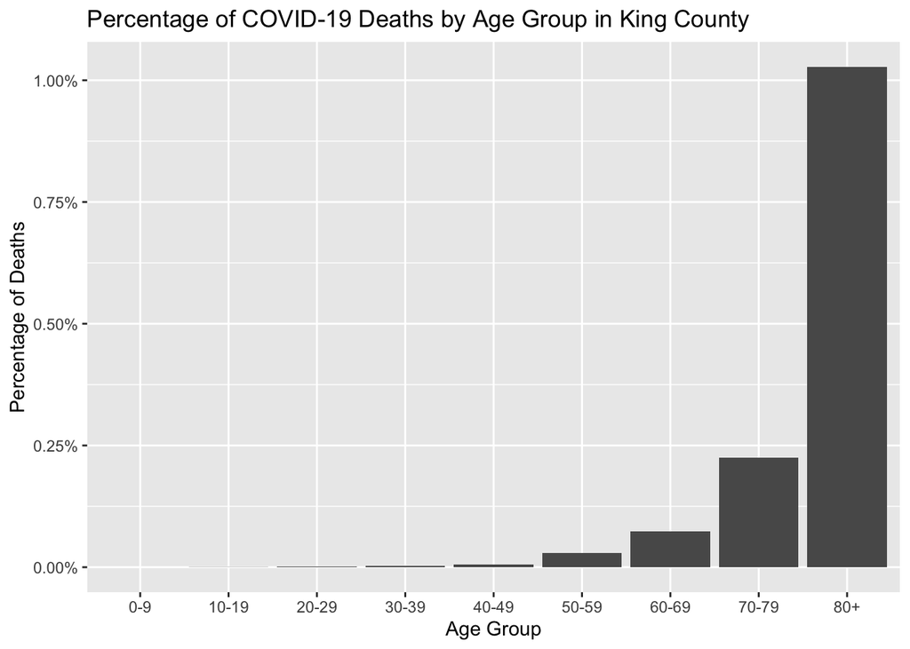

This bar graph depicts the percentage of COVID-19 related deaths by age groups of 10 years. The oldest age group (80+) had the highest percentage of deaths according to its population size, while there were 0 recorded deaths for people under 9 (in King County). This could be because children typically do not need to run errands, such as getting food, and are therefore less prone to the disease than older people. The graph shows the correlation between age and deaths, and that with the increase in age, the susceptibility to either contracting the virus or dying from it increases as well, despite variation in the size of each age group. Though 1.03% of the population dying may not seem like a lot of people upon initial glance, it is significantly higher than the percentage of deaths for the other age groups, and more than 4 times higher the second-oldest age group of 70-79.

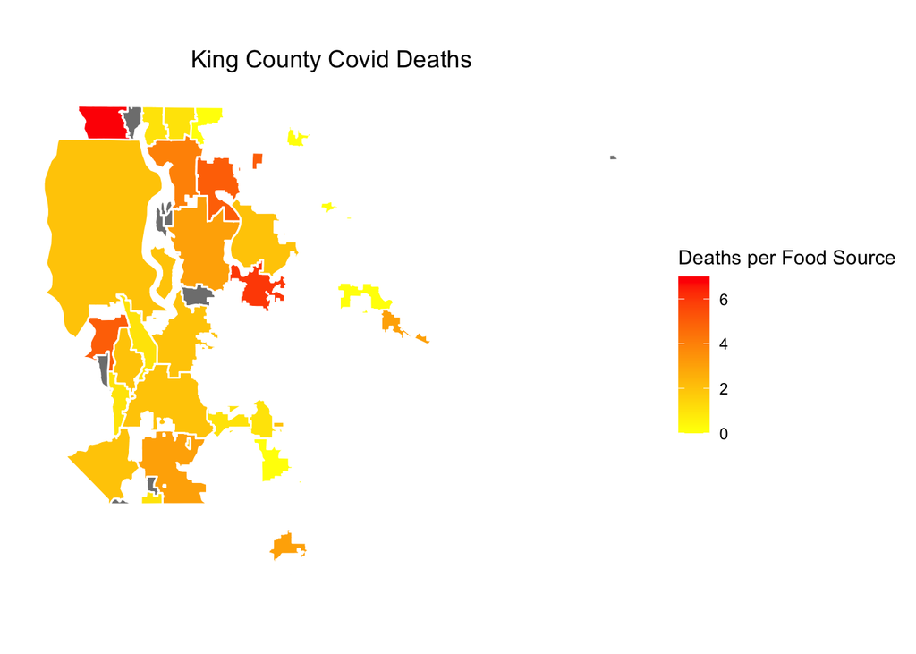

The municipality in King County with the highest concentration of COVID deaths to number of food sources seems to be the city of Shoreline and the lowest concentration seems to be in the city/cities of Black Diamond, Carnation, Duvall, Fall City, Ravensdale, Snoqualmie, Vashon, Woodinville. This table further shows relevant data for food supply and Covid deaths and positive tests and attempts to make create a comparable metric to analyze across most cities in King County. In doing this the goal is to find areas in King County that may not have adequate support in supplying food to its community.

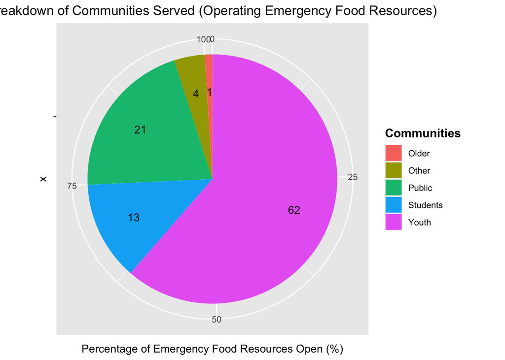

The pie chart represents a breakdown of the different communities being served at various operating emergency food resources during the COVID-19 pandemic. As we can see, among the five major communities being served, about 62% serves the Youth community, 21% serves the general public community, 1% serves the elderly community, 13% serves the students community, 4% serves the other community.  
This visualization revealed that the elderly community is one of the most under served communities during the pandemic, which is alarming considering that this community is also one of the most vulnerable.